# Assignment 3

Miguel Perez Luna

9/27/2020

I’ll be using the following libraries.

```r
library(sf)
library(tidyverse)
library(ggthemes)
library(ggspatial)
library(units)
library(nngeo)
```

## Loading the data from the Denver Open Data Catalog

The Denver Open Data Catalog had KML files available for download. However, when I went to copy the link for each file, it had a KMZ ending. I learned that this was a zipped file and using st_read() wasn’t working. So I downloaded each KMZ file, changed its .kmz ending to a .zip ending, and that let me extract the doc.kml file within the zipped file. Then, I used st_read() to open each KML file.

I selected the following layers:

Point Layer A: Afterschool Programming Locations

Point Layer B: Liquor License Locations

Polygon Layer C: Denver Neighborhoods

Polygon Layer D: Zoning Boundaries Permitting Farmers Markets

The liquor license KML file had two, what I believe were, accidental locations (which showed up in the middle of the desert in Arizona). I removed those two observations from the data frame and that let me examine liquor licenses only within Denver city limits.

```r
nhoods <- st_read("denver_neighborhoods.kml", quiet = TRUE)

farmersmarket <- st_read("farmers_market.kml", quiet = TRUE)

afterschool <- st_read("afterschool.kml", quiet = TRUE)

liquor <- st_read("liquor_licenses.kml", quiet = TRUE)

liquorlic <- liquor[-c(1306, 1654),]
```

## Transforming the data

I’ll transform my data so that its spatial data is stored using a projected coordinate system. I’ll use the NAD83 Colorado Central projection from spatialreference.org.

```r
CO_state_plane <- "+proj=lcc +lat_1=39.75 +lat_2=38.45 +lat_0=37.83333333333334 +lon_0=-105.5 +x_0=914401.8289 +y_0=304800.6096 +ellps=GRS80 +towgs84=0,0,0,0,0,0,0 +units=m +no_defs "

nhoods <- nhoods %>%
  st_transform(CO_state_plane)

afterschool <- afterschool %>%
  st_transform(CO_state_plane)

farmersmarket <- farmersmarket %>%
  st_transform(CO_state_plane)

liquorlic <- liquorlic %>%
  st_transform(CO_state_plane)
```

This is a map of the above data.

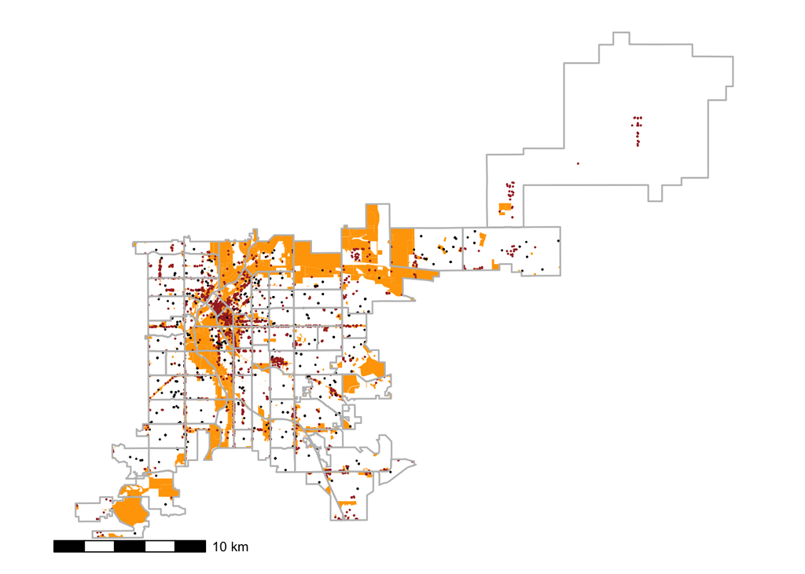

```r
ggplot(farmersmarket) +
  geom_sf(fill = "orange", color = NA) +
  geom_sf(data = liquorlic, color = "brown", size = 0.01) +
  geom_sf(data = afterschool, size = 0.01) +
  geom_sf(data= nhoods, fill = NA, color = "gray") +
  theme_map() +
  annotation_scale()
```